# Sexual Compulsivity Based on Gender

Ruisha Prasai

2023-11-15

# Introduction

Conducted an analysis to investigate how gender influences libido using the Sexual Compulsivity Scale. Participants rated 10 questions on a Likert scale (1=Not at all like me, 2=Slightly like me, 3=Mainly like me, 4=Very much like me) and provided demographic information, including gender and age. Two hypotheses were tested: Hypothesis 1 posited that the overall score is higher for ‘other’ than for ‘women’ and ‘men’, while Hypothesis 2 suggested that individuals in the ‘other’ gender category would score higher on all questions compared to women, and women would score higher compared to men. You can access the dataset on Kaggle: https://www.kaggle.com/datasets/yamqwe/sexual-compulsivity-scale/.

In subsequent sections, we will cover a detailed, step-by-step exploration, utilizing various statistical methods such as ANOVA, Regression, Tukey’s HSD and visualizations to provide insights into the relationship.

## Load and clean data

### Set up environmnet

```r
library(ggplot2)
library(ggpubr)
library(tidyverse)
library(broom)
library(emmeans)
library(AICcmodavg)
```

### Read the CSV file

```r
sexualcompulsivity.data <- read.csv("C:/Users/ruish/Downloads/Libido.csv", header = TRUE, colClasses = c("factor","factor","factor","factor","factor","factor","factor","factor","factor","factor","numeric", "numeric","numeric"))
```

### Check the structure of data to ensure it’s loaded correctly

```r
str(sexualcompulsivity.data)
```

```
## 'data.frame':    3230 obs. of  13 variables:
##  $ Q1    : Factor w/ 4 levels "1","2","3","4": 1 1 1 1 1 1 1 1 1 1 ...
##  $ Q2    : Factor w/ 4 levels "1","2","3","4": 1 1 1 1 1 1 1 1 1 1 ...
##  $ Q3    : Factor w/ 4 levels "1","2","3","4": 1 1 1 1 1 1 1 1 1 1 ...
##  $ Q4    : Factor w/ 4 levels "1","2","3","4": 1 1 1 1 1 1 1 1 1 1 ...
##  $ Q5    : Factor w/ 4 levels "1","2","3","4": 1 1 1 1 1 1 1 1 1 1 ...
##  $ Q6    : Factor w/ 4 levels "1","2","3","4": 1 1 1 1 1 1 1 1 1 1 ...
##  $ Q7    : Factor w/ 4 levels "1","2","3","4": 1 1 1 1 1 1 1 1 1 1 ...
##  $ Q8    : Factor w/ 4 levels "1","2","3","4": 1 1 1 1 1 1 1 1 1 1 ...
##  $ Q9    : Factor w/ 4 levels "1","2","3","4": 1 1 1 1 1 1 1 1 1 1 ...
##  $ Q10   : Factor w/ 4 levels "1","2","3","4": 1 1 1 1 1 1 1 1 1 1 ...
##  $ score : num  10 10 10 10 10 10 10 10 10 10 ...
##  $ gender: num  1 2 2 1 1 1 1 2 2 1 ...
##  $ age   : num  33 30 49 16 20 20 56 28 25 17 ...
```

### Check for values

```r
summary(sexualcompulsivity.data)
```

```
##  Q1      Q2       Q3       Q4       Q5       Q6       Q7       Q8      Q9
##  1:923   1:1012   1:1017   1:1438   1:1085   1: 228   1:1071   1:967   1:914
##  2:995   2: 993   2:1014   2: 921   2: 917   2: 684   2: 936   2:931   2:731
##  3:672   3: 673   3: 626   3: 480   3: 598   3: 863   3: 713   3:733   3:739
##  4:640   4: 552   4: 573   4: 391   4: 630   4:1455   4: 510   4:599   4:846
##
##
##  Q10         score           gender           age
##  1:919   Min.   :10.00   Min.   :1.000   Min.   : 14.00
##  2:677   1st Qu.:17.00   1st Qu.:1.000   1st Qu.: 22.00
##  3:669   Median :23.00   Median :1.000   Median : 28.00
##  4:965   Mean   :23.56   Mean   :1.324   Mean   : 31.27
##          3rd Qu.:29.75   3rd Qu.:2.000   3rd Qu.: 38.00
##          Max.   :40.00   Max.   :3.000   Max.   :999.00
```

### Remove outliers in ‘age’

```r
sexualcompulsivity.data$age[sexualcompulsivity.data$age >= 100] <- NA
```

### Check for values again

```r
summary(sexualcompulsivity.data)
```

```
##  Q1      Q2       Q3       Q4       Q5       Q6       Q7       Q8      Q9
##  1:923   1:1012   1:1017   1:1438   1:1085   1: 228   1:1071   1:967   1:914
##  2:995   2: 993   2:1014   2: 921   2: 917   2: 684   2: 936   2:931   2:731
##  3:672   3: 673   3: 626   3: 480   3: 598   3: 863   3: 713   3:733   3:739
##  4:640   4: 552   4: 573   4: 391   4: 630   4:1455   4: 510   4:599   4:846
##
##
##
##  Q10         score           gender           age
##  1:919   Min.   :10.00   Min.   :1.000   Min.   :14.00
##  2:677   1st Qu.:17.00   1st Qu.:1.000   1st Qu.:22.00
##  3:669   Median :23.00   Median :1.000   Median :28.00
##  4:965   Mean   :23.56   Mean   :1.324   Mean   :30.92
##          3rd Qu.:29.75   3rd Qu.:2.000   3rd Qu.:38.00
##          Max.   :40.00   Max.   :3.000   Max.   :85.00
##                                          NA's   :3
```

## Some Data Visualization

### Visualize the distribution of ‘score’ and ‘age’

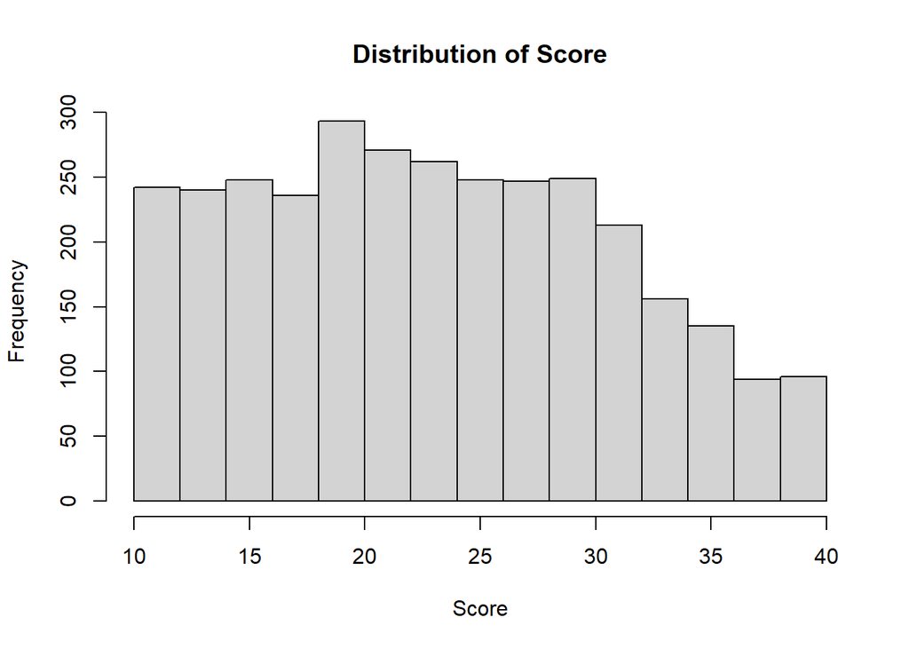

```r
hist(sexualcompulsivity.data$score, main="Distribution of Score", xlab="Score")
```

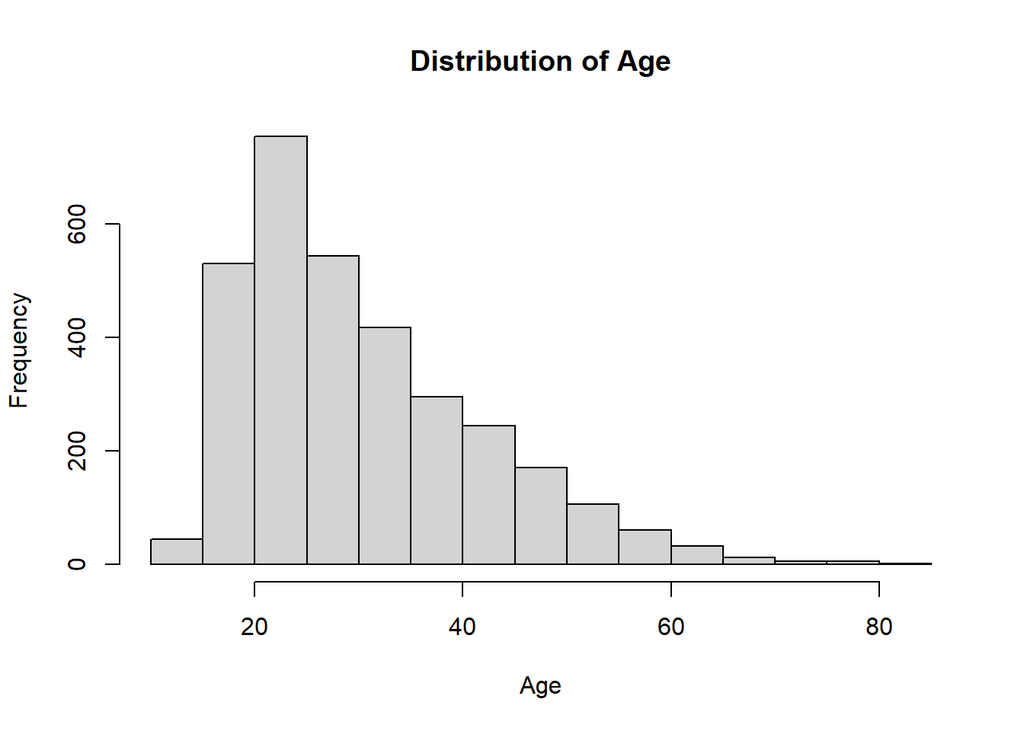

```r
hist(sexualcompulsivity.data$age, main="Distribution of Age", xlab="Age")
```

### Explore distribution of ‘gender’

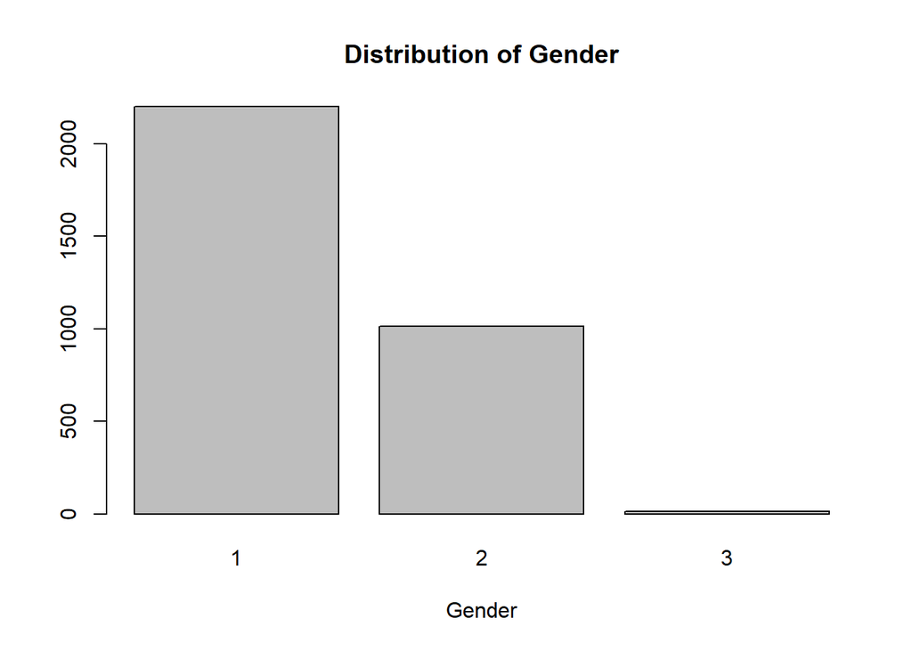

```r
barplot(table(sexualcompulsivity.data$gender), main="Distribution of Gender", xlab="Gender")
```

## Check for Hypothesis 1: overall score is greater for ‘other’ than ‘women’ and than ‘men’

One-way ANOVA between Score and Gender

```r
anova_lm <- aov(score ~ as.factor(gender), data=sexualcompulsivity.data)
summary(anova_lm)
```

```
##                     Df Sum Sq Mean Sq F value Pr(>F)
## as.factor(gender)    2    106   53.07   0.866  0.421
## Residuals         3227 197816   61.30
```

*This ANOVA output is testing whether there are significant differences in the dependent variable (e.g., ‘score’) among different gender groups (male, female, other). The F-statistic tests the overall significance, and the p-value indicates whether these differences are statistically significant. In this case, the p-value (0.421) suggests that there is no significant difference among the gender groups for the given dependent variable.*

To obtain confidence intervals for group means, post hoc test is performed.

```r
tukey_result <- TukeyHSD(anova_lm)
print(tukey_result)
```

```
##   Tukey multiple comparisons of means
##     95% family-wise confidence level
##
## Fit: aov(formula = score ~ as.factor(gender), data = sexualcompulsivity.data)
##
## $`as.factor(gender)`
##           diff        lwr       upr     p adj
## 2-1  0.2627855 -0.4338092 0.9593802 0.6501091
## 3-1 -1.8909091 -6.6471508 2.8653326 0.6199212
## 3-2 -2.1536946 -6.9287012 2.6213121 0.5405908
```

*In the Tukey multiple comparisons of means at a 95% family-wise confidence level, the analysis compares groups based on the “gender” variable from a one-way ANOVA. The results indicate that there is no statistically significant difference between groups 2 and 1, with an estimated mean difference of 0.2628 (confidence interval: -0.4338 to 0.9594) and a p-value of 0.6501. Similarly, there is no statistically significant difference between groups 3 and 1, with an estimated mean difference of -1.8909 (confidence interval: -6.6472 to 2.8653) and a p-value of 0.6199. These p-values suggest that there is no strong evidence of significant differences in “score” among these gender groups at the 0.05 significance level.*

## Check for Hypothesis 2: individuals in the ‘other’ gender category will score higher in all questions compared to women, and women will score higher compared to men

Convert ‘gender’ to a factor

```r
sexualcompulsivity.data$gender <- as.factor(sexualcompulsivity.data$gender)
```

Ensure Q1 to Q10 are numeric

```r
sexualcompulsivity.data[, 1:10] <- lapply(sexualcompulsivity.data[, 1:10], as.numeric)
```

Perform ANOVA for each questions

```r
for (i in 1:10) {
  question <- paste0("Q", i)
  formula <- as.formula(paste(question, "~ gender"))

  anova_result <- aov(formula, data = sexualcompulsivity.data)

  print(paste("ANOVA for", question))
  print(summary(anova_result))
}
```

```
## [1] "ANOVA for Q1"
##               Df Sum Sq Mean Sq F value Pr(>F)
## gender         2      0   0.153   0.129  0.879
## Residuals   3227   3827   1.186
## [1] "ANOVA for Q2"
##               Df Sum Sq Mean Sq F value Pr(>F)
## gender         2      5   2.736   2.382 0.0925 .
## Residuals   3227   3706   1.149
## ---
## Signif. codes:  0 '***' 0.001 '**' 0.01 '*' 0.05 '.' 0.1 ' ' 1
## [1] "ANOVA for Q3"
##               Df Sum Sq Mean Sq F value Pr(>F)
## gender         2      1  0.3702   0.318  0.728
## Residuals   3227   3758  1.1645
## [1] "ANOVA for Q4"
##               Df Sum Sq Mean Sq F value Pr(>F)
## gender         2      1  0.6659   0.619  0.539
## Residuals   3227   3471  1.0756
## [1] "ANOVA for Q5"
##               Df Sum Sq Mean Sq F value   Pr(>F)
## gender         2     38  19.092   15.48 2.04e-07 ***
## Residuals   3227   3980   1.233
## ---
## Signif. codes:  0 '***' 0.001 '**' 0.01 '*' 0.05 '.' 0.1 ' ' 1
## [1] "ANOVA for Q6"
##               Df Sum Sq Mean Sq F value Pr(>F)
## gender         2    3.9  1.9483   2.084  0.125
## Residuals   3227 3016.4  0.9347
## [1] "ANOVA for Q7"
##               Df Sum Sq Mean Sq F value Pr(>F)
## gender         2      0  0.0541   0.047  0.954
## Residuals   3227   3688  1.1429
## [1] "ANOVA for Q8"
##               Df Sum Sq Mean Sq F value Pr(>F)
## gender         2      2  0.7524   0.638  0.529
## Residuals   3227   3807  1.1797
## [1] "ANOVA for Q9"
##               Df Sum Sq Mean Sq F value Pr(>F)
## gender         2      4   1.775   1.325  0.266
## Residuals   3227   4321   1.339
## [1] "ANOVA for Q10"
##               Df Sum Sq Mean Sq F value Pr(>F)
## gender         2      6   3.194   2.257  0.105
## Residuals   3227   4568   1.415
```

## Below are the visualization for both of them

Visualization for Q2

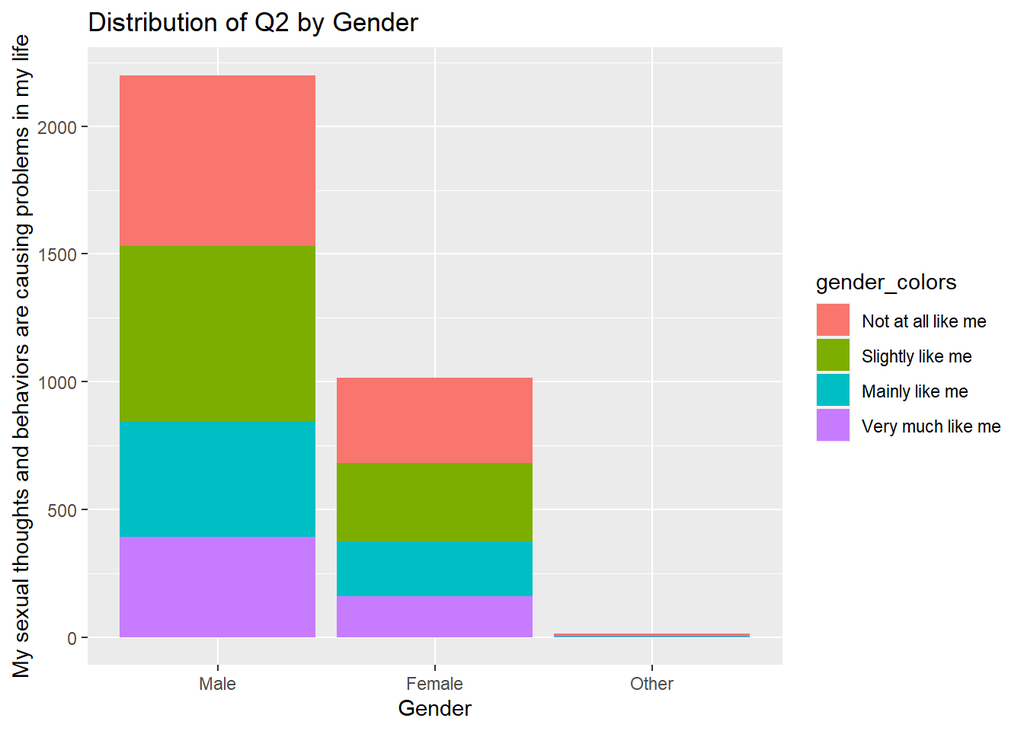

```r
gender_labels <- c("0" = "Not Answered", "1" = "Male", "2" = "Female", "3" = "Other")
gender_colors <- c("Male" = "blue", "Female" = "pink", "Other" = "purple")

ggplot(sexualcompulsivity.data, aes(x = as.factor(gender))) +
  geom_bar(aes(fill = as.factor(Q2))) +
  scale_x_discrete(labels=gender_labels) +
  scale_fill_discrete( name = "gender_colors",labels =c("Not at all like me", "Slightly like me", "Mainly like me", "Very much like me"))+
  labs(x="Gender", y="My sexual thoughts and behaviors are causing problems in my life", title = "Distribution of Q2 by Gender") +
  theme(legend.position = "right")
```

Visualization for Q5

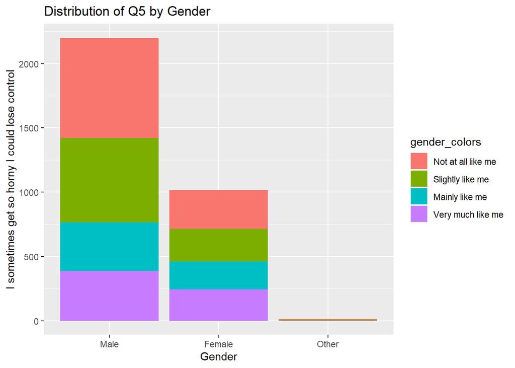

```r
gender_labels <- c("0" = "Not Answered", "1" = "Male", "2" = "Female", "3" = "Other")
gender_colors <- c("Male" = "blue", "Female" = "pink", "Other" = "purple")

ggplot(sexualcompulsivity.data, aes(x = as.factor(gender))) +
  geom_bar(aes(fill = as.factor(Q5))) +
  scale_x_discrete(labels=gender_labels) +
  scale_fill_discrete( name = "gender_colors",labels =c("Not at all like me", "Slightly like me", "Mainly like me", "Very much like me"))+
  labs(x="Gender", y="I sometimes get so horny I could lose control", title = "Distribution of Q5 by Gender") +
  theme(legend.position = "right")
```